# Lecture 7: Probability and probability distribution (discrete variables)

Mathematics and Statistics BS1515

Theodoros Arvanitopoulos

2025-11-17

# Learning objectives

### Probability and uncertainty

- Understand how to describe uncertainty using probability.
- Distinguish between different types of events (mutually exclusive, independent, etc.).
- Learn and apply key probability rules (addition, multiplication, conditional probability).
- Understand and apply Bayes’ Theorem.

### Probability distributions (discrete variables)

- Understand the difference between discrete and continuous random variables.
- Be able to calculate binomial probabilities and use the binomial distribution table.
- Calculate probabilities and expected values using R.

### 📚 Reading

Newbold et al. (2020), *Statistics for Business and Economics*, Ch. 3–4

# Concepts in Probability

### What is probability?

Probability measures the likelihood of an outcome. It ranges from 0 (impossible) to 1 (certain).

$$0 \leq P(A) \leq 1\\$$

- **Experiment**: a process with uncertain outcomes (e.g. rolling a die)
- **Sample space (S)**: the collection of all possible outcomes of a random experiment
- **Event**: any subset of basic outcomes from the sample space
- **Basic outcome**: a possible outcome of a random experiment

```r
# Example using R
S <- 1:6  # sample space for rolling a die
A <- c(2, 4, 6)  # event: rolling an even number
B <- c(4, 5, 6)  # event: rolling an even number
```

# Event relationships

As discussed on lecture 1, if A and B are two events in a sample space S:

### Union (A ∪ B)

If A and B are two events in a sample space S, then union, A U B, is the set of all outcomes in S that belong to either A or B

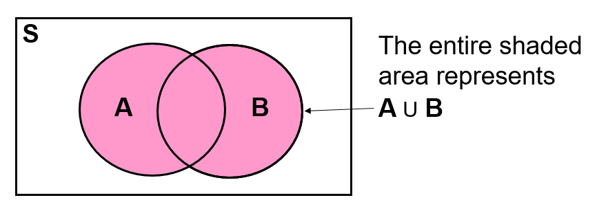

### Intersection (A ∩ B)

If A and B are two events in a sample space S, then A ∩ B is the set of all outcomes in S that belong to both A and B

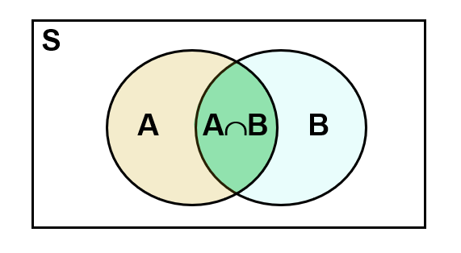

# Event relationships

### Mutually exclusive

A and B cannot both occur - there is no outcome in common, i.e A ∩ B is empty

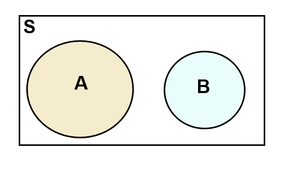

### Complement ($\bar{A}$ or A’)

The Complement of an event A is the set of all basic outcomes in the sample space that do not belong to A.So, it is the set of all outcomes in S not in A.

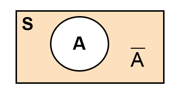

# Event relationships - R Example

```r
# Example using R - We use sets A and B

# Complement of A and B
A_comp <- setdiff(S, A)
B_comp <- setdiff(S, B)

# Union (A ∪ B)
union_AB <- union(A, B)

# Intersection (A ∩ B)
intersect_AB <- intersect(A, B)

# Output results
list(
  "Complement of A (A')" = A_comp,
  "Complement of B (B')" = B_comp,
  "Union (A ∪ B)" = union_AB,
  "Intersection (A ∩ B)" = intersect_AB
)
```

```
## $`Complement of A (A')`
## [1] 1 3 5
##
## $`Complement of B (B')`
## [1] 1 2 3
##
## $`Union (A ∪ B)`
## [1] 2 4 6 5
##
## $`Intersection (A ∩ B)`
## [1] 4 6
```

# Classical Probability

Definitions of probability. Assumes all outcomes in the sample space are equally likely to occur.

### Classical

Based on logical reasoning

$$P(A)= \frac{N_A}{N}=\frac{number \ of \ outcomes \ that \ satisfy \ the
\ event \ A}{total \ number \ of \ outcomes \ in \ the \ sample \
space}
\\$$

### Relative frequency

Based on observed data. The limit of the proportion of times that an event A occurs in a large number of trial, $n$

$$P(A)= \frac{N_A}{N}=\frac{number \ of \ events \ in \ the \ population \
that \ satisfy \ A}{total \ number \ of \ events \ in \ the \
population }
\\$$

### Subjective

Based on personal judgment. It expresses an individual’s opinion or belief about the probability of occurence.

# Number of combinations

Formula to compute the number of combinations of $n$ items taken $x$ at a time:
$$C_{x}^n =\frac{n!}{x!(n - x)!}$$

**Factorial** (!): the total number of possible ways of arranging $x$ objects in order.

The **factorial** of a positive integer $x$, denoted $x!$, is defined as:

$$x! = x (x-1) (x-2) \cdots (2) (1)$$

By convention: $0! = 1$

```r
factorial(5)    # 5!
```

```
## [1] 120
```

```r
choose(5, 2)    # 5C2
```

```
## [1] 10
```

# Classical Probability - Permutations and combinations

### Permutations

The number of possible arrangements when $x$ objects are to be selected from a total of $n$ objects (i.e. $P_x^n$) and arranged in order (with $n-x$) objects left over

**order matters**

this means that $n(n-1)(n-2)...(n-x+1)$ so that $(n-x)$ objects are left over,

multiplying and dividing the right hand side by $(n-x)(n-x-1)...(2)(1)=(n-x)!$ give us

$$P_x^n
=\frac{n(n-1)(n-2)...(n-x+1)(n-x)(n-x-1)...(2)(1)}{(n-x)(n-x-1)...(2)(1)}
\\
=\frac{n!}{(n - x)!}$$

# Classical Probability - Permutations and combinations

### Combinations

The number of combinations of $x$ objects chosen from $n$ is the number of possible selections that can be made

→ **order doesn’t matter**

$$C_{x}^n = \frac{P^n_x}{x!} \\
=\frac{n!}{x!(n - x)!}$$
and is some application, the following notation is used

$$\binom{n}{x}= C_{x}^n = \frac{n!}{x!(n - x)!}$$

### Example

$$\binom{5}{2}= C_{2}^5 = \frac{5!}{2!(5 - 1)!}=
\frac{5\times4\times3\times2\times1}{2\times1(3\times2\times1)}=10$$

# Probability Rules

### Complement

**Complement rule**: let A be an event and $\bar{A}$ its complement, then:

$$P(\bar{A}) = 1 - P(A)$$

i.e. $P(A) + P(\bar{A})=1$

# Probability Rules

### Complement

**Complement rule**: let A be an event and $\bar{A}$ its complement, then:

$$P(\bar{A}) = 1 - P(A)$$

i.e. $P(A) + P(\bar{A})=1$

### Example

For example, a company is hiring candidates for 4 identical positions. 5 candidates are from India and 3 are from the United States. Assuming that every combination of Indian and American is equally likely to be chosen, what is the probability that at least 1 American will be selected?

### Solution

First compute the probability that “no american is selected”, and then using complement rule to compute that “at least 1 American is selected”.

$P(\bar{A})=\frac{C_{4}^5}{C_{4}^8}=\frac{1}{14}$

and $P(A)=1-P(\bar{A})=1-1/14=\frac{13}{14}$

# Probability Rules

### Addition

**Addition rule**: the probability of the union of two events is
$$P(A \cup B) = P(A) + P(B) - P(A \cap B)$$

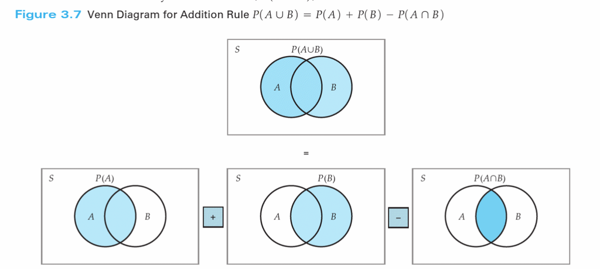

# Probability Rules

### Addition

**Addition rule**: the probability of the union of two events is
$$P(A \cup B) = P(A) + P(B) - P(A \cap B)$$

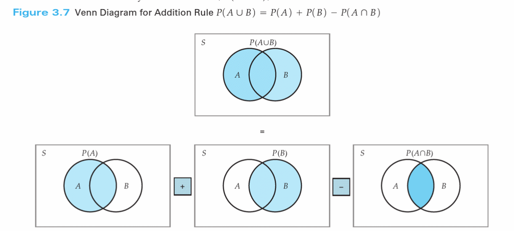

### Example

Consider a standard deck of 52 cards with four suits. Let event A be that the card is an Ace, and event B be that the card is a red suit.

$P(red \cup ace) = P(red) + P(ace) - P(red \cap ace) = 26/52 + 4/52 - 2/52 = 28/ 52 \ (aprox. 54\%)$

$P(red \cap ace)$ → we do not count the two red aces twice.

# Probability Rules

### Conditional probability

**Conditional probability** is the probability of one event, given that another event has occurred:

$$P(A \mid B) = \frac{P(A \cap B)}{P(B)} \ provided \ that \ P(B)>0$$
i.e. the conditional probability of A given that B has occurred

$$P(B \mid A) = \frac{P(A \cap B)}{P(A)} \ provided \ that \ P(A)>0$$
i.e. the conditional probability of B given that A has occurred

# Probability Rules

### Conditional probability

**Conditional probability** is the probability of one event, given that another event has occurred:

$$P(A \mid B) = \frac{P(A \cap B)}{P(B)} \ provided \ that \ P(B)>0$$
i.e. the conditional probability of A given that B has occurred

$$P(B \mid A) = \frac{P(A \cap B)}{P(A)} \ provided \ that \ P(A)>0$$
i.e. the conditional probability of B given that A has occurred

### Example

Of the cars on a used car lot, 70% have air conditioning (AC) and 40% have a CD player (CD). 20% of the cars have both.

What is the probability that a car has a CD player, given that it has AC?

$P(CD \mid AC)= \frac{C(CD \cap AC)}{P(AC)}=\frac{0.2}{0.7}=0.2857$

# Probability Rules

### Conditional probability - R example

```r
joint_probs <- matrix(c(0.2, 0.1, 0.3, 0.4), nrow = 2,
                      dimnames = list(Gender = c("M", "F"),
                                      Outcome = c("Yes", "No")))
joint_probs
```

```
##       Outcome
## Gender Yes  No
##      M 0.2 0.3
##      F 0.1 0.4
```

```r
P_Male_Yes <- joint_probs["M", "Yes"]
P_Male <- sum(joint_probs["M", ])
P_Yes_given_Male <- P_Male_Yes / P_Male
P_Yes_given_Male
```

```
## [1] 0.4
```

# Probability Rules

### Multiplication and independent events

**Multiplication** rule is the probability of their intersection that can be derived from the conditional probability

$$P(A \cap B) = P(A \mid B) P(B)$$

$$P(A \cap B) = P(B \mid A) P(A)$$

# Probability Rules

### Multiplication and independent events

**Multiplication** rule is the probability of their intersection that can be derived from the conditional probability

$$P(A \cap B) = P(A \mid B) P(B)$$

$$P(A \cap B) = P(B \mid A) P(A)$$

**Statistical independence**: Two events A and B are statistically independent when the probability of one event is not affected by the other event. Two ways to determine this:

$$2. \ P(A \cap B) = P(A)P(B)$$

# Probability Rules

### Multiplication and independent events

**Multiplication** rule is the probability of their intersection that can be derived from the conditional probability

$$P(A \cap B) = P(A \mid B) P(B)$$

$$P(A \cap B) = P(B \mid A) P(A)$$

**Statistical independence**: Two events A and B are statistically independent when the probability of one event is not affected by the other event. Two ways to determine this:

$$2. \ P(A \cap B) = P(A)P(B)$$

### Probability table

Two events A and B. Probabilities are summarised below:

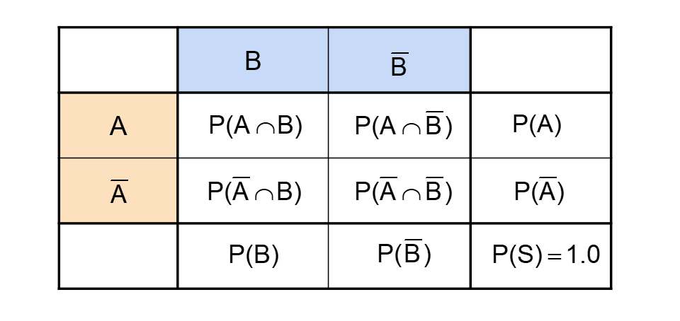

# Probability Rules

### Multiplication example

$P(red \cap ace) = P(red \mid ace) P(ace)= (2/4)(4/52)= 2/52$

### Independence example

Of the cars on a used car lot, 70% have air conditioning (AC) and 40% have a CD player (CD). 20% of the cars have both. Are the events AC and CD statistically independent?

$P(AC \cap CD) = 0.2$

$P(AC)P(CD)=(0.7)(0.4)=0.28$

So, given $P(AC \cap CD) \neq P(AC)P(CD)$, then the two events are not statistically independent

# Joint and marginal probability

The probability of a joint event, $A \cap B$:
$$P(A \cap B)= \frac{number \ \ of \ \ outcomes \ \ satisfying \ \ A \
\ and \ \ B}{total \ \ number \ \ of \ \ elementary \ \ outcomes}$$

Computing the marginal probability:

$$P(A)=P(A \cap B_1)+P(A \cap B_2)+...+P(A \cap B_k)$$

where $B_1$, $B_2$, …, $B_k$ are $k$ mutually exclusive and collectively exhaustive events.

# Joint and marginal probability

The probability of a joint event, $A \cap B$:
$$P(A \cap B)= \frac{number \ \ of \ \ outcomes \ \ satisfying \ \ A \
\ and \ \ B}{total \ \ number \ \ of \ \ elementary \ \ outcomes}$$

Computing the marginal probability:

$$P(A)=P(A \cap B_1)+P(A \cap B_2)+...+P(A \cap B_k)$$

where $B_1$, $B_2$, …, $B_k$ are $k$ mutually exclusive and collectively exhaustive events $\rightarrow$ equivalent of summing the probabilities for a particular row in the following tabl

### Example

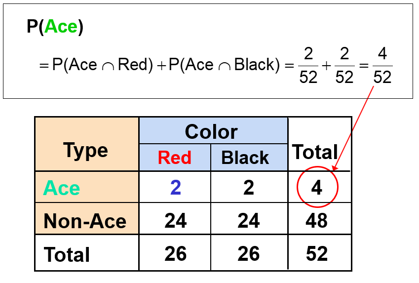

# Bayes’ Theorem

Bayes’ Theorem is a way of **revising probabilities** when new information becomes available.

It helps answer:  
> “Given that B has occurred, what is the updated probability that A is true?”

$$P(A \mid B) = \frac{P(B \mid A) P(A)}{P(B)}$$

where:

- $P(A)$: prior probability of event A
- $P(B \mid A)$: likelihood — probability of B given A
- $P(A \mid B)$: posterior — revised probability of A given B
- $P(B)$: total probability of B

# Bayes’ Theorem

### General form

**General form of Bayes’ Theorem**

The conditional probability of $E_i$ given $A$ can be expressed as:

$$P(E_i \mid A) = \frac{P(A \mid E_i) P(E_i)}{P(A) }$$
and

$$P(A)=P(A \cap E_1) + P(A \cap E_2) + ...
+ P(A \cap E_k) \\
= P(A \mid E_1)P(E_1)+P(A \mid E_2)P(E_2)+...+P(A \mid E_k)P(E_k)$$

then

$$P(E_i \mid A) = \frac{P(A \mid E_i) P(E_i)}{P(A \mid E_1) P(E_1)+ P(A
\mid E_2) P(E_2)+ ... + P(A \mid E_k) P(E_k)} \\
= \frac{P(A \mid E_i) P(E_i)}{\sum_{j=1}^{k} P(A \mid E_j) P(E_j)} \\$$

where

- let $E_1, E_2, ..., E_k$ be $k$ mutually exclusive and collectively exhaustive events
- $P(E_i)$ is the prior probability of event $E_i$
- $A$ is new event whose occurrence leads us to update the probability of $E_i$ from $P(E_i)$ to $P(A \mid E_i)$, assuming $P(A)>0$

# Bayes’ Theorem

### Example

A drilling company estimates a **40%** chance of striking oil for their new well. A detailed test is scheduled. Historically:

- 60% of successful wells had a test: $P(D \mid S) = 0.6$
- 20% of unsuccessful wells had a test: $P(D \mid U) = 0.2$

**Question**: What is the probability the well will be **successful given that** a detailed test is scheduled?

```r
# Prior probabilities
P_S <- 0.4    # P(Success)
P_U <- 0.6    # P(Unsuccessful)

# Likelihoods
P_D_given_S <- 0.6
P_D_given_U <- 0.2

# Total probability of D
P_D <- P_D_given_S * P_S + P_D_given_U * P_U

# Posterior probability using Bayes' Theorem
P_S_given_D <- (P_D_given_S * P_S) / P_D
P_S_given_D
```

```
## [1] 0.6666667
```

*Total probability*
$$P(D) = P(D \mid S)P(S) + P(D \mid U)P(U)= (0.6)(0.4) + (0.2)(0.6) = 0.24
+ 0.12 = 0.36$$
*Bayes’ Theorem*

$$P(S \mid D) = \frac{P(D \mid S)P(S)}{P(D)} = \frac{(0.6)(0.4)}{0.36} =
\frac{0.24}{0.36} = 0.667$$

So the updated probability that the well is successful, given that a test was scheduled, is **0.667**, or **66.7%**.

This is **higher than the prior** 40% estimate, because a scheduled test is **more common among successful wells**.

# Probability Distributions (discrete variables)

### Discrete vs Continuous

**Discrete random variables**:

- Finite or countable values (e.g., number of calls per day, rolling a dice twice)

**Continuous random variables**:

- Infinite values in an interval (e.g., temperature).
- So, possible values are measured in a continuum. (examples: weight, temperature, stock price).

# Probability Distributions (discrete variables)

### Discrete vs Continuous

**Discrete random variables**:

- Finite or countable values (e.g., number of calls per day, rolling a dice twice)

**Continuous random variables**:

- Infinite values in an interval (e.g., temperature).
- So, possible values are measured in a continuum. (examples: weight, temperature, stock price).

### Probability distribution of discrete random variables

Let $X$ be a discrete random variable and $x$ be one of its possible values.

The probability that random variable $X$ takes specific value $x$ is denoted $P(X = x)$.

The probability distribution function of a random variable $x$ is a representation of the probabilities for all the possible outcomes and their corresponding probabilities $P(x)$

$$0 \leq P(x) \leq 1$$
Individual probabilities should sum to 1. The notation below indicates summation over all possible $x$ values:

$$\sum{P(x)} = 1$$

# Example using R

```r
# Example: Tossing 2 coins where X = # heads
x <- 0:2
Px <- c(0.25, 0.5, 0.25)
data.frame(x, Px)
```

```
##   x   Px
## 1 0 0.25
## 2 1 0.50
## 3 2 0.25
```

```r
sum(Px)  # Should equal 1
```

```
## [1] 1
```

# Expected Value and Variance

**Expected value (or mean)** of a discrete random variable $x$
$$E(X) = \mu = \sum_{j=1}^i x_i p(x_i),$$

**Expected variance** of a discrete random variable $x$
$$\quad Var(X) = \sigma^2= E[(X-\mu]^2)] = \sum_{j=1}^i (x_i - \mu)^2
P(x_i) \\
or \\
\quad Var(X) = \sigma^2= E[(X^2-\mu^2)] = \sum_{j=1}^i x_i^2P(x_i) -
\mu^2$$

# Expected standard deviation

**Expected standard deviation** of a discrete random variable $x$

$$\quad \sigma = \sqrt{\sigma^2} = \sqrt{\sum_{j=1}^i (x_i - \mu)^2
P(x_i)}$$

# Example using R

```r
# Example: Tossing 2 coins where X = # heads
  # remember from previous example: x <- 0:2
  # remember from previous example: Px <- c(0.25, 0.5, 0.25)
  # Probabilities must sum to 1
# expected mean E(x)=1
mu <- sum(x * Px)
#expected variance
variance <- sum((x - mu)^2 * Px)
#expected standard deviation
sd <- sqrt(variance)
#list results
mu; variance; sd
```

```
## [1] 1
```

```
## [1] 0.5
```

```
## [1] 0.7071068
```

so, $\sigma=\sqrt{(0-1)^2(0.25)+(1-1)^2(0.50)+(2-1)^2(0.25)}=\sqrt{0.50}=0.707$

where 0, 1, and 2 are the possible number of heads.

# Binomial Distribution

Among the **discreet probability distributions** there are the binomial, the Poisson, etc. In this lecture, we will focus on the **binomial** distribution:

### Characteristics

A fixed number of observations, $n$

- e.g., 15 tosses of a coin

Two mutually exclusive and collectively exhaustive categories

- e.g., “success” and “failure”

Constant probability for each observation

- e.g. Probability of getting a tail is the same each time we toss the coin

Observations are independent

- i.e. outcome of one observation does not affect the outcome of the other

# Binomial Distribution

### Probability

Number of sequences with $x$ successes in $n$ independent trials with success probability $p$:

$$P(X = x) = \frac{n!}{x!(n-x)!}p^x(1-p)^{n - x} \\
= \binom{n}{x} p^x (1 - p)^{n - x}$$

where

- $P(x)$ is a the probability of $x$ ‘successes’ ($x=0,1,2,3,..,n$)
- $n$ trials (our sample here)
- $P$ probability of “success” in each independent trial

# Binomial Distribution

### Mean and Variance

**Mean** (expected value)
$$\mu = \mathbb{E}[X] = np \qquad$$

**Variance** and **standard deviation**
$$\sigma^2 = \text{Var}(X) = np(1 - p) \qquad \\
\sigma = \sqrt{np(1-p)} \\$$
where $n$ is the sample size, $P$ is the probability of success, $(1-P)$ is the probability of failure.

**Interpretation:**

- Over many repetitions of the experiment, you *expect* about $np$ successes per set of $n$ trials.
- The variance captures how much the number of successes varies around that average.

# Binomial Distribution

### Using binomial tables

Given that we know the sample size $n$, the number of sequences with $x$ successes, and the probability of “success” $P$ in each independent trial,

then we can use the binomial tables that usually can be found in the appendices of Statistics textbooks, so that we find $P(x)$.

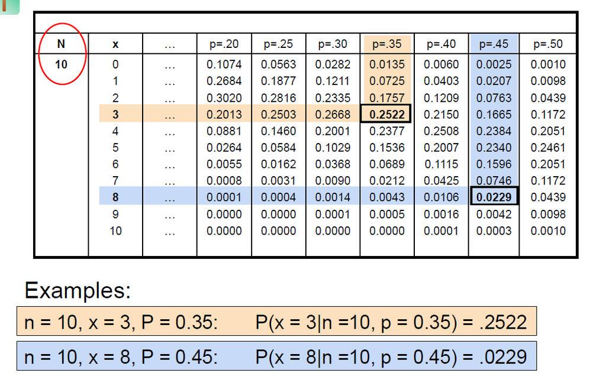